# DSCI Shark Project

Ikemonso

2023-05-01

## Data Wrangling & Cleaning

```r
#Download the data set and the appropriate libraries
library(readr)
library(tidyverse)
library(lubridate)
library(dplyr)
library(mdsr)
library(janitor)
library(stringr)
library(stringi)
library(ggfittext)
library(ISOweek)
attacks <- read_csv("/Users/ikospiko/Desktop/DATA_PROJECTS/Nintendo_DS/Shark Analysis Project/Data/attacks.csv")
```

```
## ──────────────────────────────────────────────────────── Delimiter: "," chr
## (20): Case Number...1, Date, Type, Country, Area, Location, Activity, Na... dbl
## (2): Year, original order
```

```r
#Check the class for every column for reference
ref <- data.frame(sapply(attacks,class))

#The case number columns are filled with redundant data from the date column. We'll keep one Case number column and leave out the rest. We'll also leave out the href, pdf, area, age, and location info, as these are not relevant to our study and country will suffice for spatial queries. We want to study only complete shark attack cases, so we will omit any data that doesn't at least have at least a case number, a date, and a fatality measure (for a query later on).
shark_attacks <- attacks %>%
  select(`Case Number...1`, Date, Year, Type, Country, Area, Location, Activity, Name, Sex, Injury, Fatal = `Fatal (Y/N)`, Species, `Investigator or Source`) %>%
#Remove spaces from column names
  rename(Source = `Investigator or Source`,
         Case_Number = `Case Number...1`) %>%
#Mutate Date to a date format
  mutate(Date = ymd(Date),
         Fatal = ifelse(Fatal %in% c("Y", "N"), Fatal,
                        ifelse(tolower(Fatal) == "y", "Y", NA)),
         Month = month(Date, label = TRUE)) %>%
  drop_na(Date) %>%
  drop_na(Case_Number)
```

```r
#Next we will fix the species name column to properly address the sharks we'll be studying. First, we render any NA values as "Unidentified".
shark_attacks$Species[is.na(shark_attacks$Species)] <- "Unidentified"

#Create a function to remove any measurements in shark species
format_string <- function(string){
  string <- unlist(str_extract_all(string, "([A-Za-z]+)"))
  string <- string[str_length(string) > 2]
  string <- str_to_lower(paste(string, collapse = " "))
  string
}

#Map across all species
shark_attacks$Updated_Species <-  unlist(map(shark_attacks$Species, format_string))

#Create numerous columns for new shark names
shark_attacks <- shark_attacks %>%
  mutate(New_Species = case_when(
    str_detect(Updated_Species,"albimarginatus")~"Silvertip shark",
    str_detect(Updated_Species,"angel shark")~"Angel shark",
    str_detect(Updated_Species,"banjo")~"Banjo shark",
    str_detect(Updated_Species,"blacktip reef shark|caribbean reef shark|reef shark|gray reef|grey")~"Reef shark",
    str_detect(Updated_Species,"blacktip shark|limbatus")~"Blacktip shark",
    str_detect(Updated_Species,"spinner shark")~"Spinner shark",
    str_detect(Updated_Species,"blue whaler|blue")~"Blue shark",
    str_detect(Updated_Species,"sevengill shark|gill shark")~"Broadnose Sevengill shark",
    str_detect(Updated_Species,"bronze whaler")~"Copper shark",
    str_detect(Updated_Species,"bull shark|leucas|zambezi shark|zambesi shark|zambezi shark")~"Bull shark",
    str_detect(Updated_Species,"lemon shark")~"Lemon shark",
    str_detect(Updated_Species,"tiger shark")~"Tiger shark",
    str_detect(Updated_Species,"sandbar shark|brown")~"Sandbar shark",
    str_detect(Updated_Species,"white shark")~"Great white shark",
    str_detect(Updated_Species,"copper shark")~"Copper shark",
    str_detect(Updated_Species,"cow shark")~"Cow shark",
    str_detect(Updated_Species,"dogfish shark|spurdog")~"Dogfish shark",
    str_detect(Updated_Species,"dusky shark")~"Dusky shark",
    str_detect(Updated_Species,"galapagos shark")~"Galapagos shark",
    str_detect(Updated_Species,"gummy shark")~"Gummy shark",
    str_detect(Updated_Species,"hammerhead")~"Hammerhead shark",
    str_detect(Updated_Species,"heterodontus francisci")~"Horn shark",
    str_detect(Updated_Species,"dogfish scyliorhinus canicula")~"Small-spotted Catshark",
    str_detect(Updated_Species,"mako shark|shortfin mako shark")~"Shortfin Mako shark",
    str_detect(Updated_Species,"carcharhinid shark")~"Requiem shark",
    str_detect(Updated_Species,"nurse shark")~"Nurse shark",
    str_detect(Updated_Species,"oceanic whitetip")~"Oceanic whitetip shark",
    str_detect(Updated_Species,"porbeagle shark")~"Porbeagle shark",
    str_detect(Updated_Species,"port jackson shark")~"Port Jackson shark",
    str_detect(Updated_Species,"raggedtooth shark|sand shark")~"Sand shark",
    str_detect(Updated_Species,"salmon shark")~"Salmon shark",
    str_detect(Updated_Species,"silky shark")~"Silky shark",
    str_detect(Updated_Species,"whale shark")~"Whale shark",
    str_detect(Updated_Species,"thresher shark")~"Thresher shark",
    str_detect(Updated_Species,"cookie cutter shark")~"Cookie-Cutter shark",
    str_detect(Updated_Species,"wobbegong")~"Wobbegong shark",
    str_detect(Updated_Species,"shark|unidentified")~"Unidentified",
    TRUE~"Not shark"
    )
) %>%
  filter(!is.na(Fatal)) %>%
#Now we'll select the columns we'll use
  select(Case_Number, Name, Sex, Fatal, Date, Year, Month, Country, Activity, Type, Injury, New_Species, Source)

#Check the amount of NA's to confirm Case and Date are removed. Use summarize to count the number of NA values in each column and pivot to visualize just how much data is NA
is_it_na <- shark_attacks %>%
  summarise_all(funs(sum(is.na(.)))) %>%
  pivot_longer(everything() , names_to = "Columns", values_to = "Sum_NA") %>%
  filter(Columns == "Case_Number" | Columns == "Date" | Columns =="Year")
is_it_na
```

```
## # A tibble: 3 × 2
##   Columns     Sum_NA
##   <chr>        <int>
## 1 Case_Number      0
## 2 Date             0
## 3 Year             0
```

```r
#No NA's, let's get to work.
View(shark_attacks)
```

## Untruth…or Unlucky?

### Let’s first see how many people - if any - are either reporting it for publicity stunt or are just that unlucky! We’ll measure this by checking for any repeats

```r
#First we'll create a table without any fatalities whatsoever and see if any names pop up
unluck <- shark_attacks %>%
  drop_na(Name) %>%
  filter(!str_detect(Injury, "\\b[Ff]ATAL\\b") |
         !str_detect(Injury, "\\b[Ff]atal\\b") |
          (Fatal == "Y" & !is.na(Fatal))) %>%
  mutate(Newname = (Name = TRUE) + 0) %>%
  group_by(Name) %>%
  summarize(NameCount = sum(Newname)) %>%
  filter(NameCount > 1) %>%
  arrange(-NameCount)

unluck
```

```
## # A tibble: 59 × 2
##    Name         NameCount
##    <chr>            <dbl>
##  1 male               355
##  2 female              72
##  3 boy                 14
##  4 Anonymous           10
##  5 boat                 8
##  6 2 males              6
##  7 Unidentified         6
##  8 child                6
##  9 a sailor             5
## 10 Unknown              4
## # ℹ 49 more rows
```

```r
#We seem to have lots of identity pointers but not a lot of names. We'll filter so we just have first and last names to check for any liars (*ahem* I mean unfortunate individuals) and see what we get
first_and_last <- shark_attacks %>%
  drop_na(Name) %>%
  filter(!str_detect(Injury, "\\b[Ff]ATAL\\b") |
         !str_detect(Injury, "\\b[Ff]atal\\b") |
          (Fatal != "Y" & !is.na(Fatal))) %>%
  filter(str_detect(Name, "\\b[A-Z][a-z]+\\s[A-Z][a-z]+\\b") |
         str_detect(Name, "\\b[A-Z][a-z]+\\s?[A-Za-z]*\\s[A-Z][a-z]+\\b")) %>%
  mutate(Name = str_replace(Name, "boat, occupant: Danie Schoeman", "Danie Schoeman"),
         Name = str_replace(Name, "skiDanie Schoeman", "Danie Schoeman"),
         Name = str_replace(Name, "Rory O\x92Connor", "Rory O'Conner")) %>%
  mutate(Newname = (Name = TRUE) + 0) %>%
  group_by(Name) %>%
  summarize(NameCount = sum(Newname)) %>%
  filter(NameCount > 1) %>%
  arrange(-NameCount)

first_and_last
```

```
## # A tibble: 22 × 2
##    Name              NameCount
##    <chr>                 <dbl>
##  1 Danie Schoeman            4
##  2 Andre Hartman             3
##  3 Andy Austin               2
##  4 Anton Bosman              2
##  5 Carey Ford                2
##  6 Gary Johnson              2
##  7 Gerjo Van Niekerk         2
##  8 Gordon Harmer             2
##  9 Greg Pickering            2
## 10 Hans Hass                 2
## # ℹ 12 more rows
```

```r
#Looks like we have a couple of potential liars (or repeats if you want to be specific), let's make a function that gives us their injuries so we can check for matches
#Pull the names from the list into a new vector to use an input data
liar_names <- unlist(first_and_last$Name)

#Create a function to pull injuries with at least one matching word
liar_func <- function(name){
  shark_attacks %>%
    drop_na(Name) %>%
  filter(!str_detect(Injury, "\\b[Ff]ATAL\\b") |
         !str_detect(Injury, "\\b[Ff]atal\\b") |
          (Fatal != "Y" & !is.na(Fatal))) %>%
  filter(str_detect(Name, "\\b[A-Z][a-z]+\\s[A-Z][a-z]+\\b") |
         str_detect(Name, "\\b[A-Z][a-z]+\\s?[A-Za-z]*\\s[A-Z][a-z]+\\b")) %>%
  mutate(Name = str_replace(Name, "boat, occupant: Danie Schoeman", "Danie Schoeman"),
         Name = str_replace(Name, "skiDanie Schoeman", "Danie Schoeman"),
         Name = str_replace(Name, "Rory O\x92Connor", "Rory O'Conner")) %>%
    filter(Name == name) %>%
#Added a second non-Fatal filter because R wants them to be dead, I suppose
    filter(Fatal != "Y") %>%
    select(Name, Injury)
}
liar_df <- map_df(liar_names, liar_func)
liar_df
```

```
## # A tibble: 41 × 2
##    Name           Injury
##    <chr>          <chr>
##  1 Danie Schoeman No injury to occupant: shark bit boat's port chine
##  2 Danie Schoeman No injury to occupants. Hooked shark bit boat's transom, PROV…
##  3 Danie Schoeman No injury to occupant, shark holed boat
##  4 Danie Schoeman No injury to occupant, but  a shark chasing a hooked fish hol…
##  5 Andre Hartman  Right ankle & foot lacerated
##  6 Andre Hartman  No injury, shark bit speargun & pushed diver through the water
##  7 Andre Hartman  Left knee lacerated
##  8 Andy Austin    Calf bitten
##  9 Andy Austin    3 small punctures on arm
## 10 Anton Bosman   No injury
## # ℹ 31 more rows
```

So, looks like we have no liars after all! It does seem as though we have some that incidents of provocation, but none of the same person. We did find one person that the table deemed unlucky, though. Iona Asai with the injury: Head, neck & shoulder bitten (In 1918, he was also bitten by a shark off Cairns). We’ll consider humans good…for now.

## Sharks…Love-Bites or Fatalities

### Next, let’s look at the level of these injuries. Obviously there are many fatalities, but we want to see what kind of injuries are most prevalent and if all the fatalities we see on the news or movies are the majority after all.

```r
#First we'll make the tables of no injuries, regular injuries (everything in between death and a paper cut), and fatal injuries. I'll do a filter case for how one injury should NOT be another and DESIRED specifier
no_injury <- shark_attacks %>%
  filter(str_detect(Injury, "\\b[Nn]o\\s[Ii]njury\\b") &
        !str_detect(Injury, "\\b[Ff]ATAL\\b") &
        !str_detect(Injury, "\\b[Ff]atal\\b") &
        (Fatal != "Y")) %>%
  mutate(Injury_detect = (Injury = "NONE")) %>%
  select(Case_Number, Injury_detect, Injury)

normal_injury <- shark_attacks %>%
   filter(!str_detect(Injury, "\\b[Nn]o\\s[Ii]njury\\b") &
          !str_detect(Injury, "\\b[Ff]ATAL\\b") &
          !str_detect(Injury, "\\b[Ff]atal\\b") &
          (Fatal != "Y")) %>%
  mutate(Injury_detect = (Injury = "NORMAL")) %>%
  select(Case_Number, Injury_detect, Injury)

fatal_injury <- shark_attacks %>%
  filter(!str_detect(Injury, "\\b[Nn]o\\s[Ii]njury\\b") &
         (str_detect(Injury, "\\b[Ff]ATAL\\b") |
          str_detect(Injury, "\\b[Ff]atal\\b")) &
        (Fatal == "Y")) %>%
  mutate(Injury_detect = (Injury = "FATAL")) %>%
  select(Case_Number, Injury_detect, Injury)

#Join all three tables and plot the cases with the new Injury Detect column, fixing some double-assignments
Injuries <- no_injury %>%
  full_join(normal_injury, by = "Case_Number") %>%
  full_join(fatal_injury, by = "Case_Number") %>%
  mutate(CaseCount = (Case_Number = TRUE) + 0) %>%
  unite("Injury_Detect", Injury_detect.x, Injury_detect.y, Injury_detect, sep = ", ") %>%
  mutate(Injury_Detect = str_replace_all(Injury_Detect, "NONE, NA, NA", "NONE")) %>%
  mutate(Injury_Detect = str_replace_all(Injury_Detect, "NONE, NORMAL, NA", "NONE")) %>%
  mutate(Injury_Detect = str_replace_all(Injury_Detect, "NA, NORMAL, NA", "NORMAL")) %>%
  mutate(Injury_Detect = str_replace_all(Injury_Detect, "NA, NORMAL, FATAL", "FATAL")) %>%
  mutate(Injury_Detect = str_replace_all(Injury_Detect, "NA, NA, FATAL", "FATAL")) %>%
  mutate(Injury_Detect = factor(Injury_Detect, levels = c("NONE", "NORMAL", "FATAL"))) %>%
  group_by(Injury_Detect) %>%
  summarize(Cases = sum(CaseCount))
Injuries
```

```
## # A tibble: 3 × 2
##   Injury_Detect Cases
##   <fct>         <dbl>
## 1 NONE            635
## 2 NORMAL         3136
## 3 FATAL           882
```

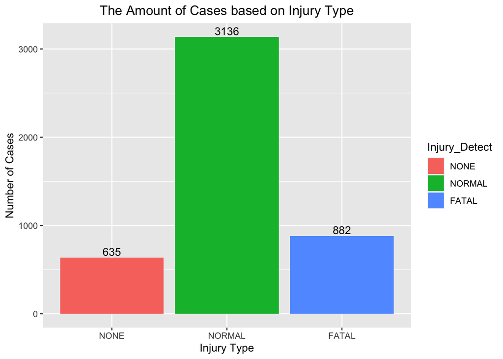

```r
#Let's plot
Injury_plot <- ggplot(aes(x = Injury_Detect, y = Cases), data = Injuries) +
  geom_col(aes(fill = Injury_Detect), stat = "identity") +
  geom_text(aes(label= Cases), position=position_dodge(width=0.9), vjust=-0.25) +
  labs(title = "The Amount of Cases based on Injury Type", x = "Injury Type", y = "Number of Cases") +
  theme(plot.title = element_text(hjust = 0.5))
Injury_plot
```

As we can see, the amount of shark attacks that were fatal were vastly lower than that of livable, yet still unfortunate, attacks (and were only slightly higher than attacks with no injuries at all). As Chris Evans famously said whilst playing Captain America in *Age of Ultron*, “You get killed, walk it off”.

## Equal Opportunity Sharks

### With our data we can also look at the amount of shark attacks with male and female victims stratified by country, finally answering life’s greatest question: “Are sharks sexist? And if they are, which ones?”

```r
#First we drop NA values and create a table with our limited gender inputs (male and female) and take the top 5 countries with the highest male and female count
sexist_sharks <- shark_attacks %>%
  filter(!is.na(Sex) &
         (Sex == "M" | Sex == "F")) %>%
  mutate(s_count = (Sex = TRUE) + 0) %>%
  group_by(Sex, Country) %>%
  summarize(Gender_Count = sum(s_count)) %>%
  pivot_wider(names_from = Sex, values_from = Gender_Count) %>%
  arrange(-F, -M) %>%
  head(5)
```

[output not shown]

```r
sexist_sharks
```

```
## # A tibble: 5 × 3
##   Country          F     M
##   <chr>        <dbl> <dbl>
## 1 USA            298  1532
## 2 AUSTRALIA       73   853
## 3 SOUTH AFRICA    22   436
## 4 NEW ZEALAND     13    60
## 5 BAHAMAS         12    74
```

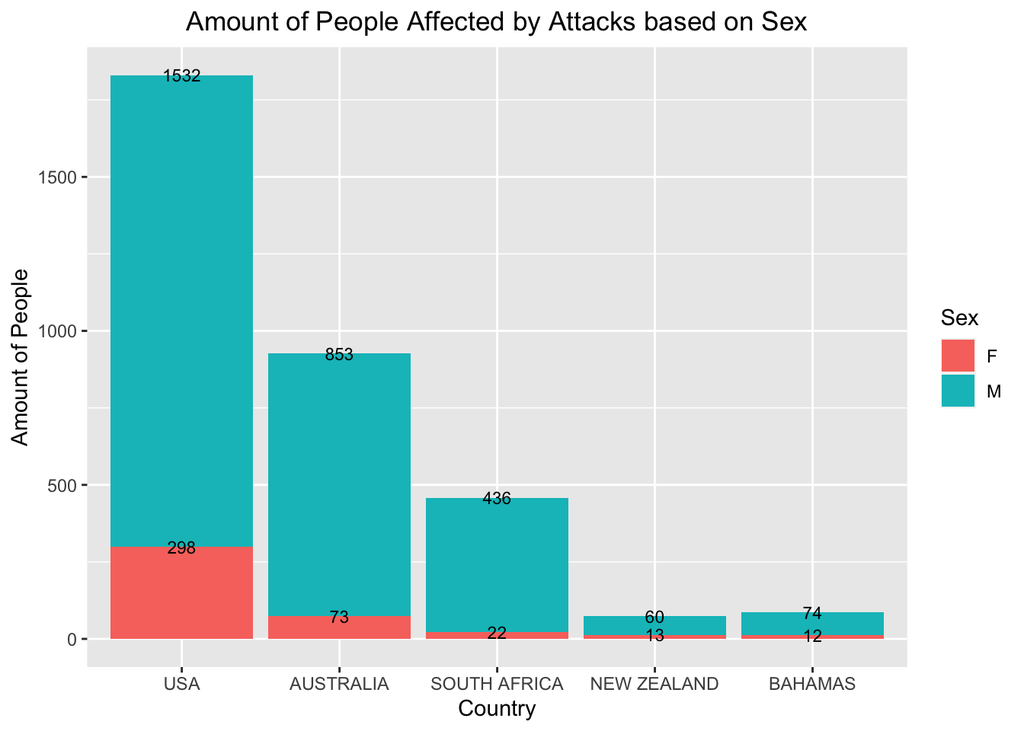

```r
#Now that we have the data, we'll reshape it back to the original long format for a nice visualization
s_plot_data <- sexist_sharks %>%
  pivot_longer(cols = c("M", "F"), names_to = "Sex", values_to = "Gender_Count") %>%
  mutate(Country = factor(Country, levels = c("USA",    "AUSTRALIA","SOUTH AFRICA", "NEW ZEALAND", "BAHAMAS")))

s_plot <- ggplot(aes(x = Country, y = Gender_Count, fill = Sex, label = Gender_Count),
                 data = s_plot_data) +
  geom_col(position = position_stack(reverse = TRUE)) +
  labs(title = "Amount of People Affected by Attacks based on Sex", x = "Country",
       y = "Amount of People") +
  theme(plot.title = element_text(hjust = 0.5)) +
  geom_text(position = position_stack(reverse = TRUE), size = 3)

s_plot
```

Well we can officially breathe a sigh of relief! There seems to be a majority of males in the top three countries with the most known (specifically gender-assigned) victims of attacks. We could learn a thing or two from sharks. Lesson One: Get rid of the men.

## The True Bullies of the Sea

### Let’s look at the amount of sharks that’ve given people the most trouble in comparison with the amount PEOPLE that have given sharks the most trouble (i.e., sharks that were either unprovoked or provoked).

```r
#First let's look at all the instances of provoked shark accidents vs. unprovoked
#Let's reference how many NA's there are in the Type column
sum(is.na(shark_attacks$Type))
```

```
## [1] 1
```

```r
#We have one so we'll fix that as well as a truer Type column
provocation <- shark_attacks %>%
  mutate(Provocation = ifelse(is.na(shark_attacks$Type), "Unknown",
                              ifelse(shark_attacks$Type == "Provoked" |
                                       str_detect(shark_attacks$Injury, regex("provoked", ignore_case = TRUE)), "Provoked",
                                     ifelse(shark_attacks$Type == "Unprovoked" |
                                              str_detect(shark_attacks$Injury, regex("unprovoked", ignore_case = TRUE)), "Unprovoked", "Inconclusive"))),
         Provcount = (Provocation = TRUE) + 0) %>%
  group_by(Provocation) %>%
  summarize(Provocation_Count = sum(Provcount)) %>%
  mutate(Provocation = factor(Provocation, levels = c("Unknown", "Provoked", "Inconclusive", "Unprovoked")))
provocation
```

```
## # A tibble: 4 × 2
##   Provocation  Provocation_Count
##   <fct>                    <dbl>
## 1 Inconclusive               777
## 2 Provoked                   467
## 3 Unknown                      1
## 4 Unprovoked                3631
```

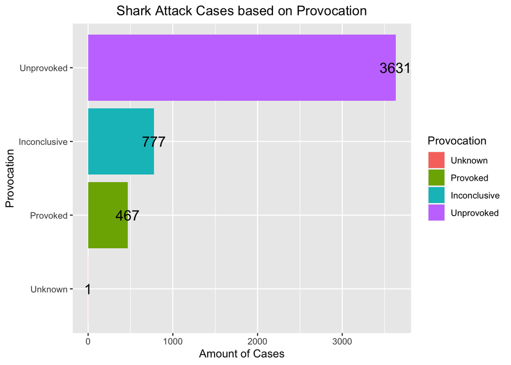

```r
#Let's visualize
provocation_graph <- ggplot(aes(x = Provocation, y = Provocation_Count, fill = Provocation, label = Provocation_Count), data = provocation) +
  geom_col() +
  labs(title = "Shark Attack Cases based on Provocation",
       y = "Amount of Cases") +
  theme(plot.title = element_text(hjust = 0.5)) +
  geom_text(size = 5) +
  coord_flip()

provocation_graph
```

```r
#Now let's see which shark, specifically is the shark responsible for the most attacks
angriest_shark <- shark_attacks %>%
  mutate(Provocation = ifelse(is.na(shark_attacks$Type), "Unknown",
                              ifelse(shark_attacks$Type == "Provoked" |
                                       str_detect(shark_attacks$Injury, regex("provoked", ignore_case = TRUE)), "Provoked",
                                     ifelse(shark_attacks$Type == "Unprovoked" |
                                              str_detect(shark_attacks$Injury, regex("unprovoked", ignore_case = TRUE)), "Unprovoked", "Inconclusive"))),
         Provcount = (Provocation = TRUE) + 0) %>%
  group_by(Provocation, New_Species) %>%
  summarize(Provocation_Count = sum(Provcount)) %>%
  mutate(Provocation = factor(Provocation, levels = c("Unknown", "Provoked", "Inconclusive", "Unprovoked"))) %>%
  filter(New_Species != "Unidentified") %>%
  arrange(-Provocation_Count) %>%
  head(1) %>%
  pull(New_Species)
angriest_shark
```

```
## [1] "Great white shark"
```

Provoked, in this case, means that people had done some action to “egg the shark on”. And, as we can see, humans are not perfect. Now, it may not be a surprise that the species responsible for the most attacks happens to be Great white shark. There might always be some stigmas against Great Whites and Bull sharks for being “dangerous” or “scary” and some data to show that, but resident shark expert, Avalon Butler, claims that, “They’re the dogs of the sea[…]they’re just super curious about everything[…]most shark attacks from Great Whites aren’t meant to endanger us[…]they’re just curious about how humans are and the only way sharks can investigate is through biting!”

## Shark of the Century!

### Now that we’ve established location, we’ll also see if any trends can be gleaned from the years, specifically the centures because years are basic

```r
#Amount of cases by date and month
shark_year <- shark_attacks %>%
  mutate(casect = (Case_Number = TRUE) + 0) %>%
  mutate(Century = cut(Year, breaks = seq(1600, 2100, by = 100), labels = c("17th", "18th", "19th", "20th", "21st"), include.lowest = TRUE)) %>%
  group_by(Century) %>%
  summarize(Case_Count = sum(casect))

shark_year
```

```
## # A tibble: 5 × 2
##   Century Case_Count
##   <fct>        <dbl>
## 1 17th             1
## 2 18th             9
## 3 19th            57
## 4 20th          3107
## 5 21st          1702
```

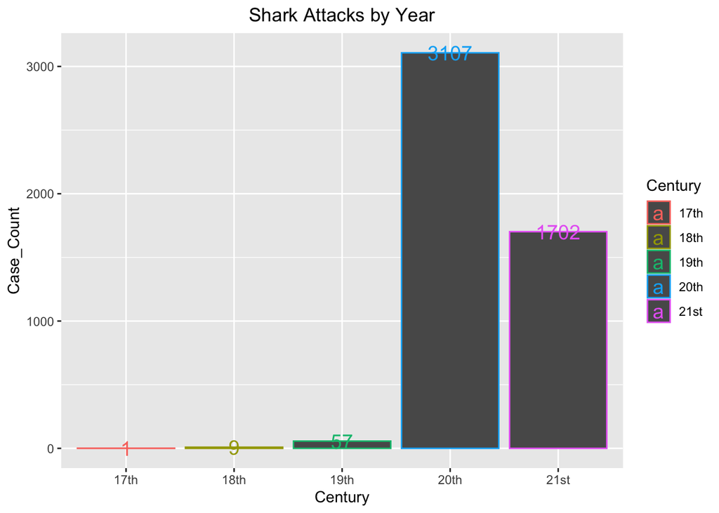

```r
#Let's plot
ggplot(shark_year, aes(x = Century, y = Case_Count, label = Case_Count, color = Century)) +
  geom_col() +
  labs(title = "Shark Attacks by Year",
       x = "Century",
       y = "Case_Count") +
  scale_x_discrete(labels = c("17th", "18th", "19th", "20th", "21st")) +
  theme(plot.title = element_text(hjust = 0.5)) +
  geom_text(size = 5)
```

## Shark Week

### For the little grand finale, we will also find every year’s true Shark Week: The week where there were the most shark attacks.

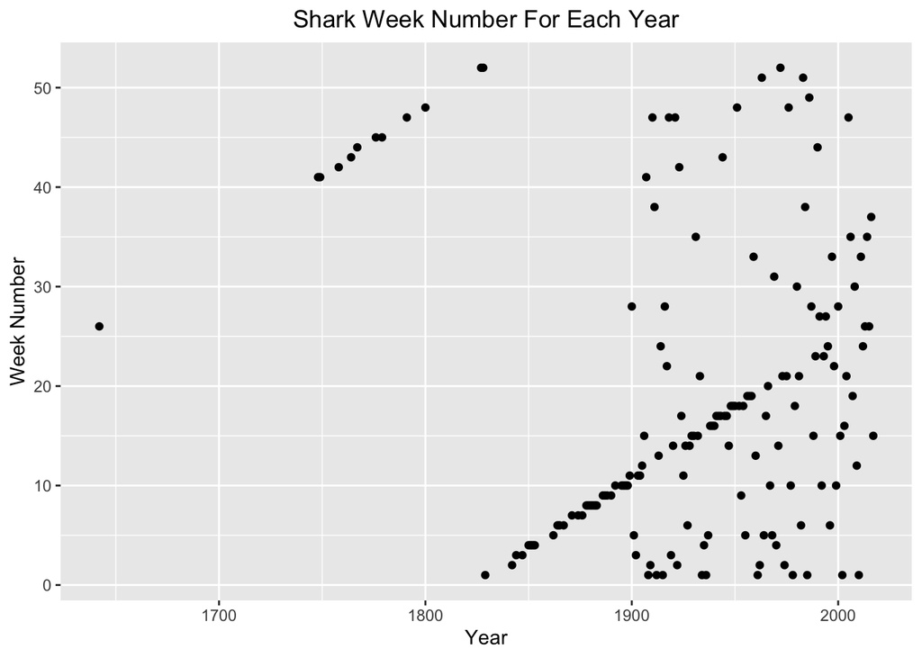

```r
s_week <- function(year){
  shark_attacks %>%
    filter(Year == year) %>%
    mutate(casect3 = (Case_Number = TRUE) + 0) %>%
    mutate(Week = isoweek(Date)) %>%
    group_by(Week) %>%
    summarize(Case_Count = sum(casect3)) %>%
    arrange(-Case_Count) %>%
    head(1) %>%
    pull(Week)
}

#We'll use a list of all the years in our data set to map and then visualize results
Yearlist <- unique(shark_attacks$Year)

shark_map <- unlist(map(Yearlist, s_week))
#Now we'll extract the date ranges by reformatting the dates with a formula. This uses week number to add the number of days until the first day of that week and then 6 more to represent the last day
shark_week <- data_frame(Year = Yearlist, Week_Number = shark_map) %>%
  mutate(Week = str_c(format(as.Date(paste0(Year, "-01-01")) + (Week_Number - 1) * 7, "%B %d"),
                      format(as.Date(paste0(Year, "-01-01")) + (Week_Number - 1) * 7 + 6, " - %B %d, %Y"),
                      sep = " "))
#To help with visualization
shark_week_plot <- shark_week %>%
  ggplot(aes(x = Year, y = Week_Number)) +
  geom_point() +
  labs(title = "Shark Week Number For Each Year", x = "Year",
       y = "Week Number") +
  theme(plot.title = element_text(hjust = 0.5))

shark_week_plot
```

```r
#How many were in the second half of the year?
first_half <- shark_week %>%
  filter(Week_Number <= 26) %>%
  nrow()

first_half
```

```
## [1] 118
```

```r
second_half <- shark_week %>%
  filter(Week_Number > 26) %>%
  nrow()

second_half
```

```
## [1] 43
```

Looks like April 09 - April 15, 2017 was the last “shark week” that the data would celebrate, and it seems that many years had their own shark week in the first half of the year with 118 in the first half and 43 in the second.

## Thank you for looking at my project!

Credit: https://www.kaggle.com/datasets/mysarahmadbhat/shark-attacks